# Supervised Learning - Foundations: ReCell

*Marks: 60*

## Context

Buying and selling used phones and tablets used to be something that happened on a handful of online marketplace sites. But the used and refurbished device market has grown considerably over the past decade, and a new IDC (International Data Corporation) forecast predicts that the used phone market would be worth \$52.7bn by 2023 with a compound annual growth rate (CAGR) of 13.6% from 2018 to 2023. This growth can be attributed to an uptick in demand for used phones and tablets that offer considerable savings compared with new models.

Refurbished and used devices continue to provide cost-effective alternatives to both consumers and businesses that are looking to save money when purchasing one. There are plenty of other benefits associated with the used device market. Used and refurbished devices can be sold with warranties and can also be insured with proof of purchase. Third-party vendors/platforms, such as Verizon, Amazon, etc., provide attractive offers to customers for refurbished devices. Maximizing the longevity of devices through second-hand trade also reduces their environmental impact and helps in recycling and reducing waste. The impact of the COVID-19 outbreak may further boost this segment as consumers cut back on discretionary spending and buy phones and tablets only for immediate needs.

## Objective

The rising potential of this comparatively under-the-radar market fuels the need for an ML-based solution to develop a dynamic pricing strategy for used and refurbished devices. ReCell, a startup aiming to tap the potential in this market, has hired you as a data scientist. They want you to analyze the data provided and build a linear regression model to predict the price of a used phone/tablet and identify factors that significantly influence it.

## Data Description

The data contains the different attributes of used/refurbished phones and tablets. The detailed data dictionary is given below.

**Data Dictionary**

- brand_name: Name of manufacturing brand
- os: OS on which the device runs
- screen_size: Size of the screen in cm
- 4g: Whether 4G is available or not
- 5g: Whether 5G is available or not
- main_camera_mp: Resolution of the rear camera in megapixels
- selfie_camera_mp: Resolution of the front camera in megapixels
- int_memory: Amount of internal memory (ROM) in GB
- ram: Amount of RAM in GB
- battery: Energy capacity of the device battery in mAh
- weight: Weight of the device in grams
- release_year: Year when the device model was released
- days_used: Number of days the used/refurbished device has been used
- new_price: Price of a new device of the same model in euros
- used_price: Price of the used/refurbished device in euros

## Importing necessary libraries and data

```python
## lets import our libraries
import os
import numpy as np
import pandas as pd
import matplotlib.pyplot as plt
import seaborn as sns

sns.set()

from sklearn.model_selection import train_test_split

from sklearn.linear_model import LinearRegression

from sklearn.metrics import mean_squared_error
```

## Data Overview

```python
## load the data
df = pd.read_csv("used_device_data.csv")
```

```python
## brief overivew of data
df.head()
```

|  | brand_name | os | screen_size | 4g | 5g | main_camera_mp | selfie_camera_mp | int_memory | ram | battery | weight | release_year | days_used | new_price | used_price |
| --- | --- | --- | --- | --- | --- | --- | --- | --- | --- | --- | --- | --- | --- | --- | --- |
| 0 | Honor | Android | 14.50 | yes | no | 13.0 | 5.0 | 64.0 | 3.0 | 3020.0 | 146.0 | 2020 | 127 | 111.62 | 74.26 |
| 1 | Honor | Android | 17.30 | yes | yes | 13.0 | 16.0 | 128.0 | 8.0 | 4300.0 | 213.0 | 2020 | 325 | 249.39 | 174.53 |
| 2 | Honor | Android | 16.69 | yes | yes | 13.0 | 8.0 | 128.0 | 8.0 | 4200.0 | 213.0 | 2020 | 162 | 359.47 | 165.85 |
| 3 | Honor | Android | 25.50 | yes | yes | 13.0 | 8.0 | 64.0 | 6.0 | 7250.0 | 480.0 | 2020 | 345 | 278.93 | 169.93 |
| 4 | Honor | Android | 15.32 | yes | no | 13.0 | 8.0 | 64.0 | 3.0 | 5000.0 | 185.0 | 2020 | 293 | 140.87 | 80.64 |

```python
## lets get a quick description of the data
df.info()
```

```
<class 'pandas.core.frame.DataFrame'>
RangeIndex: 3454 entries, 0 to 3453
Data columns (total 15 columns):
 #   Column            Non-Null Count  Dtype
---  ------            --------------  -----
 0   brand_name        3454 non-null   object
 1   os                3454 non-null   object
 2   screen_size       3454 non-null   float64
 3   4g                3454 non-null   object
 4   5g                3454 non-null   object
 5   main_camera_mp    3275 non-null   float64
 6   selfie_camera_mp  3452 non-null   float64
 7   int_memory        3450 non-null   float64
 8   ram               3450 non-null   float64
 9   battery           3448 non-null   float64
 10  weight            3447 non-null   float64
 11  release_year      3454 non-null   int64
 12  days_used         3454 non-null   int64
 13  new_price         3454 non-null   float64
 14  used_price        3454 non-null   float64
dtypes: float64(9), int64(2), object(4)
memory usage: 404.9+ KB
```

```python
## lets show a summary of the numerical attributes
df.describe()
```

|  | screen_size | main_camera_mp | selfie_camera_mp | int_memory | ram | battery | weight | release_year | days_used | new_price | used_price |
| --- | --- | --- | --- | --- | --- | --- | --- | --- | --- | --- | --- |
| count | 3454.000000 | 3275.000000 | 3452.000000 | 3450.000000 | 3450.000000 | 3448.000000 | 3447.000000 | 3454.000000 | 3454.000000 | 3454.000000 | 3454.000000 |
| mean | 13.713115 | 9.460208 | 6.554229 | 54.573099 | 4.036122 | 3133.402697 | 182.751871 | 2015.965258 | 674.869716 | 237.038848 | 92.302936 |
| std | 3.805280 | 4.815461 | 6.970372 | 84.972371 | 1.365105 | 1299.682844 | 88.413228 | 2.298455 | 248.580166 | 194.302782 | 54.701648 |
| min | 5.080000 | 0.080000 | 0.000000 | 0.010000 | 0.020000 | 500.000000 | 69.000000 | 2013.000000 | 91.000000 | 18.200000 | 4.650000 |
| 25% | 12.700000 | 5.000000 | 2.000000 | 16.000000 | 4.000000 | 2100.000000 | 142.000000 | 2014.000000 | 533.500000 | 120.342500 | 56.482500 |
| 50% | 12.830000 | 8.000000 | 5.000000 | 32.000000 | 4.000000 | 3000.000000 | 160.000000 | 2015.500000 | 690.500000 | 189.785000 | 81.870000 |
| 75% | 15.340000 | 13.000000 | 8.000000 | 64.000000 | 4.000000 | 4000.000000 | 185.000000 | 2018.000000 | 868.750000 | 291.115000 | 116.245000 |
| max | 30.710000 | 48.000000 | 32.000000 | 1024.000000 | 12.000000 | 9720.000000 | 855.000000 | 2020.000000 | 1094.000000 | 2560.200000 | 749.520000 |

```python
## determining the length of the dataset
len(df)
```

```
3454
```

```python
## check tthe data type
df.dtypes
```

```
brand_name           object
os                   object
screen_size         float64
4g                   object
5g                   object
main_camera_mp      float64
selfie_camera_mp    float64
int_memory          float64
ram                 float64
battery             float64
weight              float64
release_year          int64
days_used             int64
new_price           float64
used_price          float64
dtype: object
```

## Exploratory Data Analysis (EDA)

- EDA is an important part of any project involving data.
- It is important to investigate and understand the data better before building a model with it.
- A few questions have been mentioned below which will help you approach the analysis in the right manner and generate insights from the data.
- A thorough analysis of the data, in addition to the questions mentioned below, should be done.

**Questions**:

1. What does the distribution of used device prices look like?
2. What percentage of the used device market is dominated by Android devices?
3. The amount of RAM is important for the smooth functioning of a device. How does the amount of RAM vary with the brand?
4. A large battery often increases a device's weight, making it feel uncomfortable in the hands. How does the weight vary for phones and tablets offering large batteries (more than 4500 mAh)?
5. Bigger screens are desirable for entertainment purposes as they offer a better viewing experience. How many phones and tablets are available across different brands with a screen size larger than 6 inches?
6. Budget devices nowadays offer great selfie cameras, allowing us to capture our favorite moments with loved ones. What is the distribution of budget devices offering greater than 8MP selfie cameras across brands?
7. Which attributes are highly correlated with the price of a used device?

### Distribution Of The Target Variable (Used Device Prices)

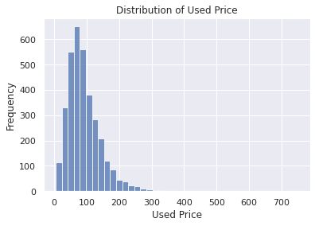

```python
## distribution of used device prices
plt.figure(figsize=(6, 4))

sns.histplot(df.used_price, bins=40)
plt.ylabel('Frequency')
plt.xlabel('Used Price')
plt.title('Distribution of Used Price')

plt.show()
```

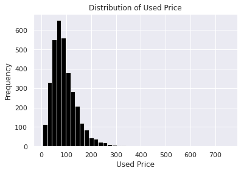

```python
## distribution of used device prices
plt.figure(figsize=(6, 4))

sns.histplot(df.used_price, bins=40, color='black', alpha=1)
plt.ylabel('Frequency')
plt.xlabel('Used Price')
plt.title('Distribution of Used Price')

plt.show()
```

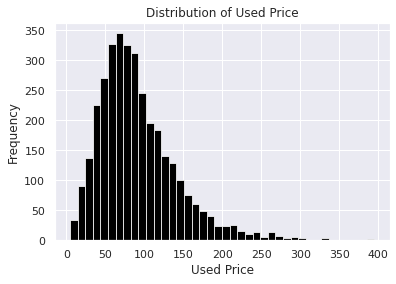

```python
## distribution of used device prices
plt.figure(figsize=(6, 4))

sns.histplot(df.used_price[df.used_price < 400], bins=40, color='black', alpha=1)
plt.ylabel('Frequency')
plt.xlabel('Used Price')
plt.title('Distribution of Used Price')

plt.show()
```

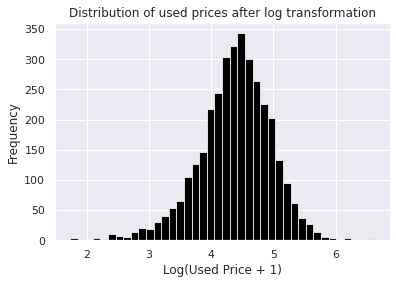

```python
## apply log transformation to the target variable
## to negate the effect of the long-tail distribution
log_used_price = np.log1p(df.used_price)

plt.figure(figsize=(6,4))

sns.histplot(log_used_price, bins=40, color='black', alpha=1)
plt.ylabel('Frequency')
plt.xlabel('Log(Used Price + 1)')
plt.title('Distribution of used prices after log transformation')

plt.show()
```

```python
# function to create labeled barplots

def labeled_barplot(data, feature, perc=False, n=None):
    """
    Barplot with percentage at the top

    data: dataframe
    feature: dataframe column
    perc: whether to display percentages instead of count (default is False)
    n: displays the top n category levels (default is None, i.e., display all levels)
    """

    total = len(data[feature])  # length of the column
    count = data[feature].nunique()
    if n is None:
        plt.figure(figsize=(count + 1, 5))
    else:
        plt.figure(figsize=(n + 1, 5))

    plt.xticks(rotation=90, fontsize=15)
    ax = sns.countplot(
        data=data,
        x=feature,
        palette="Paired",
        order=data[feature].value_counts().index[:n].sort_values(),
    )

    for p in ax.patches:
        if perc == True:
            label = "{:.1f}%".format(
                100 * p.get_height() / total
            )  # percentage of each class of the category
        else:
            label = p.get_height()  # count of each level of the category

        x = p.get_x() + p.get_width() / 2  # width of the plot
        y = p.get_height()  # height of the plot

        ax.annotate(
            label,
            (x, y),
            ha="center",
            va="center",
            size=12,
            xytext=(0, 5),
            textcoords="offset points",
        )  # annotate the percentage

    plt.show()  # show the plot
```

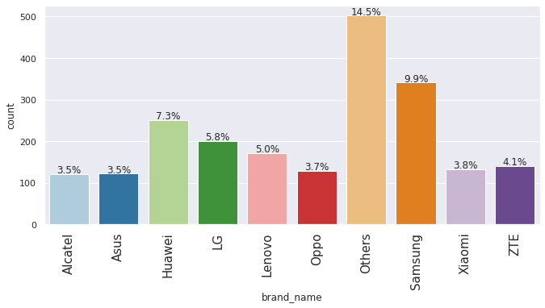

```python
labeled_barplot(df, "brand_name", perc=True, n=10)
```

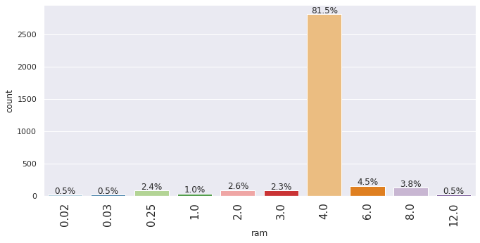

```python
labeled_barplot(df, "ram", perc=True, n=10)
```

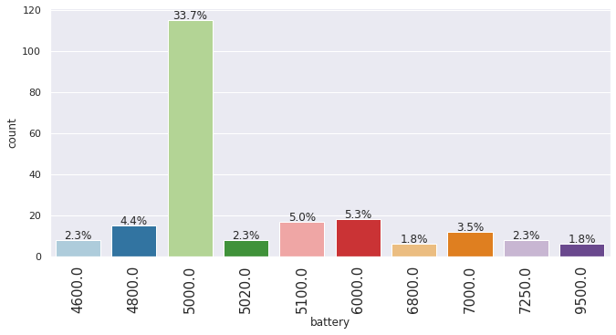

```python
labeled_barplot(df[df['battery'] > 4500], "battery", perc=True, n=10)
```

### Distribution of screen_size larger than 6

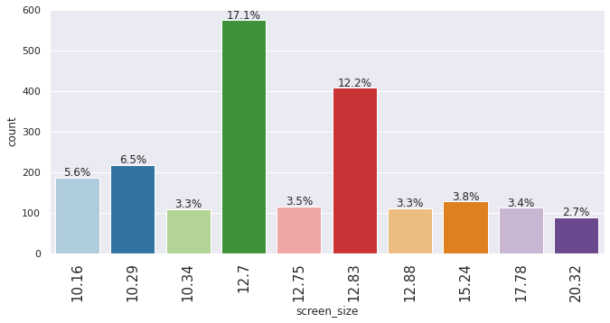

```python
labeled_barplot(df[df['screen_size'] > 6], "screen_size", perc=True, n=10)
```

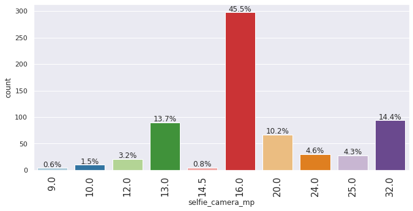

```python
labeled_barplot(df[df['selfie_camera_mp'] > 8], "selfie_camera_mp",  perc=True, n=10)
```

### Finding the Correlations Of Attributes with Used price

The correlation coefficient ranges from –1 to 1. When it is close to 1, it means that there is a strong positive correlation;

```python
corr_matrix = df.corr()
```

```python
corr_matrix["used_price"].sort_values(ascending=False)
```

```
used_price          1.000000
new_price           0.809335
selfie_camera_mp    0.614675
battery             0.549647
ram                 0.529434
screen_size         0.529275
release_year        0.494910
main_camera_mp      0.459209
int_memory          0.378347
weight              0.357983
days_used          -0.385777
Name: used_price, dtype: float64
```

## EDA

- It is a good idea to explore the data once again after manipulating it.

## Data Preprocessing

- Missing value treatment
- Feature engineering (if needed)
- Outlier detection and treatment (if needed)
- Preparing data for modeling
- Any other preprocessing steps (if needed)

```python
## lets check for missing values
df.isnull().sum()
```

```
brand_name            0
os                    0
screen_size           0
4g                    0
5g                    0
main_camera_mp      179
selfie_camera_mp      2
int_memory            4
ram                   4
battery               6
weight                7
release_year          0
days_used             0
new_price             0
used_price            0
dtype: int64
```

```python
## lets fill the missing values with zeros
df = df.fillna(0)
```

### Validation framework

This involes splitting our dataset into the following rations

```python
df_train_full, df_valid = train_test_split(df, test_size=0.2, random_state=1)

df_train, df_test = train_test_split(df_train_full, test_size=0.33 ,random_state=11)

print(f"Validation set: {len(df_valid)}")
print(f"Test set: {len(df_test)}")
print(f"Train set: {len(df_train)}")
```

```
Validation set: 691
Test set: 912
Train set: 1851
```

```python
## lets select our target data
## and apply log transformation
## to ofset the long-tail effect

y_train = np.log1p(df_train.used_price.values)
y_valid = np.log1p(df_valid.used_price.values)
y_test = np.log1p(df_test.used_price.values)
```

```python
## lets delete the target variable column
del df_train['used_price']
del df_valid['used_price']
del df_test['used_price']
```

## Building a Linear Regression model

### Baseline

let build a build a baseline solution by selecting few of the numeric feautres

```python
base = ['main_camera_mp', 'ram', 'int_memory', 'days_used', 'new_price', 'selfie_camera_mp', 'release_year']

df_num = df_train[base]
```

```python
## lets check for missing values
df_num.isnull().sum()
```

```
main_camera_mp      0
ram                 0
int_memory          0
days_used           0
new_price           0
selfie_camera_mp    0
release_year        0
dtype: int64
```

```python
## lets convert our dataframe into a numpy array
X_train = df_num.values
```

```python
## lets train our model
## create an instance of the model
## and fit the data
liner_reg_model = LinearRegression()
liner_reg_model.fit(X_train, y_train)
```

```
LinearRegression()
```

```python
## lets generate some predictions with the training data
y_train_pred = liner_reg_model.predict(X_train)
```

## Model performance evaluation

### Evaluating baseline model

```python
## lets evaluate our base line model using root_mean_squard_error

mse = mean_squared_error(y_train, y_train_pred)
rmse = np.sqrt(mse)
print(f'Accuracy of baseline model: {rmse}')
```

```
Accuracy of baseline model: 0.34013846341611614
```

### Validating baseline model

```python
##
df_num = df_valid[base]
X_valid = df_num.values
```

```python
## lets generate our validation predictions
y_valid_pred = liner_reg_model.predict(X_valid)
```

```python
## compute the accuracy of the validation dataset.
mse = mean_squared_error(y_valid, y_valid_pred)
rmse = np.sqrt(mse)
print(f'Accuracy of Validation baseline model: {rmse}')
```

```
Accuracy of Validation baseline model: 0.31389547630279846
```

## Feature Engineering

By encoding categorical data into our model building

```python
categorical_var_1 = ['5g', '4g']
df_train = df_train[categorical_var_1 + base]
train_dict = df_train.to_dict(orient='records')
```

```python
from sklearn.feature_extraction import DictVectorizer

dv = DictVectorizer(sparse=False)
dv.fit(train_dict)

X_train = dv.transform(train_dict)
```

```python
## instantiate and train model
liner_reg_model_2 = LinearRegression()
liner_reg_model_2.fit(X_train, y_train)

## predictions
y_train_pred = liner_reg_model_2.predict(X_train)
```

```python
##accuracy
rme = mean_squared_error(y_train, y_train_pred)
rmse = np.sqrt(rme)
print(f'Traning Accuracy After Feature Engineering: {rmse}')
```

```
Traning Accuracy After Feature Engineering: 0.3353186946678645
```

```python
## check the validation accuracy
valid_dict = df_valid[base + categorical_var_1].to_dict(orient='records')

X_valid = dv.transform(valid_dict)
```

```python
## generate validation predictions
y_pred_valid = liner_reg_model_2.predict(X_valid)
```

```python
##accuracy
rme = mean_squared_error(y_valid, y_pred_valid)
rmse = np.sqrt(rme)
print(f'Validation Accuracy After Feature Engineering: {rmse}')
```

```
Validation Accuracy After Feature Engineering: 0.31321921841190337
```

## Checking Linear Regression Assumptions

- In order to make statistical inferences from a linear regression model, it is important to ensure that the assumptions of linear regression are satisfied.

### Linearity

```python
def calculate_residuals(model, features, label):
    """
    Creates predictions on the features with the model and calculates residuals
    """
    predictions = model.predict(features)
    df_results = pd.DataFrame({'Actual': label, 'Predicted': predictions})
    df_results['Residuals'] = abs(df_results['Actual']) - abs(df_results['Predicted'])

    return df_results
```

```python
def linear_assumption(model, features, label):
    """
    Linearity: Assumes that there is a linear relationship between the predictors and
               the response variable. If not, either a quadratic term or another
               algorithm should be used.
    """
    print('Assumption 1: Linear Relationship between the Target and the Feature', '\n')

    print('Checking with a scatter plot of actual vs. predicted.',
           'Predictions should follow the diagonal line.')

    # Calculating residuals for the plot
    df_results = calculate_residuals(model, features, label)

    # Plotting the actual vs predicted values
    sns.lmplot(x='Actual', y='Predicted', data=df_results, fit_reg=False, size=7)

    # Plotting the diagonal line
    line_coords = np.arange(df_results.min().min(), df_results.max().max())
    plt.plot(line_coords, line_coords,  # X and y points
             color='darkorange', linestyle='--')
    plt.title('Actual vs. Predicted')
    plt.show()
```

Test for Linearity for Train data

```
Assumption 1: Linear Relationship between the Target and the Feature

Checking with a scatter plot of actual vs. predicted. Predictions should follow the diagonal line.
```

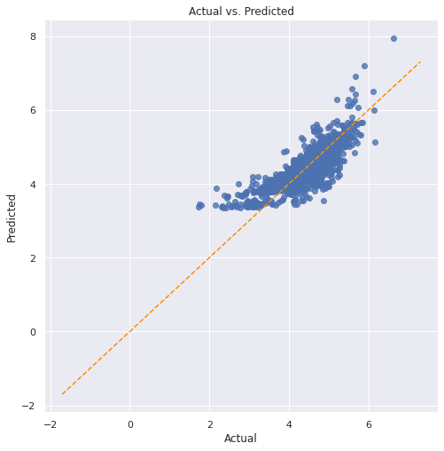

```python
linear_assumption(liner_reg_model_2, X_train, y_train)
```

Test for Linearity for Validation data

```
Assumption 1: Linear Relationship between the Target and the Feature

Checking with a scatter plot of actual vs. predicted. Predictions should follow the diagonal line.
```

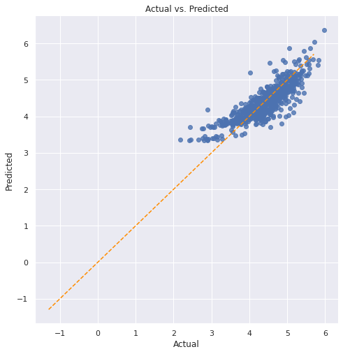

```python
linear_assumption(liner_reg_model_2, X_valid, y_valid)
```

### Normality of the Error Terms

```python
def normal_errors_assumption(model, features, label, p_value_thresh=0.05):
    """
    Normality: Assumes that the error terms are normally distributed. If they are not,
    nonlinear transformations of variables may solve this.

    This assumption being violated primarily causes issues with the confidence intervals
    """
    from statsmodels.stats.diagnostic import normal_ad
    print('Assumption 2: The error terms are normally distributed', '\n')

    # Calculating residuals for the Anderson-Darling test
    df_results = calculate_residuals(model, features, label)

    print('Using the Anderson-Darling test for normal distribution')

    # Performing the test on the residuals
    p_value = normal_ad(df_results['Residuals'])[1]
    print('p-value from the test - below 0.05 generally means non-normal:', p_value)

    # Reporting the normality of the residuals
    if p_value < p_value_thresh:
        print('Residuals are not normally distributed')
    else:
        print('Residuals are normally distributed')

    # Plotting the residuals distribution
    plt.subplots(figsize=(12, 6))
    plt.title('Distribution of Residuals')
    sns.distplot(df_results['Residuals'])
    plt.show()

    print()
    if p_value > p_value_thresh:
        print('Assumption satisfied')
    else:
        print('Assumption not satisfied')
        print()
        print('Confidence intervals will likely be affected')
        print('Try performing nonlinear transformations on variables')
```

Test for normality for train data

```
Assumption 2: The error terms are normally distributed

Using the Anderson-Darling test for normal distribution
p-value from the test - below 0.05 generally means non-normal: 3.873801750253289e-26
Residuals are not normally distributed
```

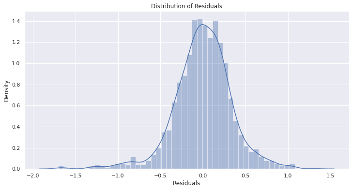

```
Assumption not satisfied

Confidence intervals will likely be affected
Try performing nonlinear transformations on variables
```

```python
normal_errors_assumption(liner_reg_model_2, X_train, y_train)
```

Test for normality for validation data

```
Assumption 2: The error terms are normally distributed

Using the Anderson-Darling test for normal distribution
p-value from the test - below 0.05 generally means non-normal: 1.0424235177686293e-06
Residuals are not normally distributed
```

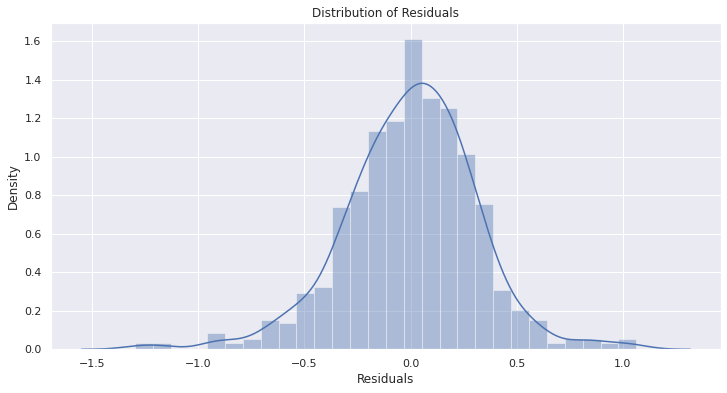

```
Assumption not satisfied

Confidence intervals will likely be affected
Try performing nonlinear transformations on variables
```

```python
normal_errors_assumption(liner_reg_model_2, X_valid, y_valid)
```

### Multicollinearity among Predictors

```python
def multicollinearity_assumption(model, features, label, feature_names=None):
    """
    Multicollinearity: Assumes that predictors are not correlated with each other. If there is
                       correlation among the predictors, then either remove prepdictors with high
                       Variance Inflation Factor (VIF) values or perform dimensionality reduction

                       This assumption being violated causes issues with interpretability of the
                       coefficients and the standard errors of the coefficients.
    """
    from statsmodels.stats.outliers_influence import variance_inflation_factor
    print('Assumption 3: Little to no multicollinearity among predictors')

    # Plotting the heatmap
    plt.figure(figsize = (10,8))
    sns.heatmap(pd.DataFrame(features, columns=feature_names).corr(), annot=True)
    plt.title('Correlation of Variables')
    plt.show()

    print('Variance Inflation Factors (VIF)')
    print('> 10: An indication that multicollinearity may be present')
    print('> 100: Certain multicollinearity among the variables')
    print('-------------------------------------')

    # Gathering the VIF for each variable
    VIF = [variance_inflation_factor(features, i) for i in range(features.shape[1])]
    for idx, vif in enumerate(VIF):
        print('{0}: {1}'.format(feature_names[idx], vif))

    # Gathering and printing total cases of possible or definite multicollinearity
    possible_multicollinearity = sum([1 for vif in VIF if vif > 10])
    definite_multicollinearity = sum([1 for vif in VIF if vif > 100])
    print()
    print('{0} cases of possible multicollinearity'.format(possible_multicollinearity))
    print('{0} cases of definite multicollinearity'.format(definite_multicollinearity))
    print()

    if definite_multicollinearity == 0:
        if possible_multicollinearity == 0:
            print('Assumption satisfied')
        else:
            print('Assumption possibly satisfied')
            print()
            print('Coefficient interpretability may be problematic')
            print('Consider removing variables with a high Variance Inflation Factor (VIF)')

    else:
        print('Assumption not satisfied')
        print()
        print('Coefficient interpretability will be problematic')
        print('Consider removing variables with a high Variance Inflation Factor (VIF)')
```

Test for multicollinearity for train data

```
Assumption 3: Little to no multicollinearity among predictors
```

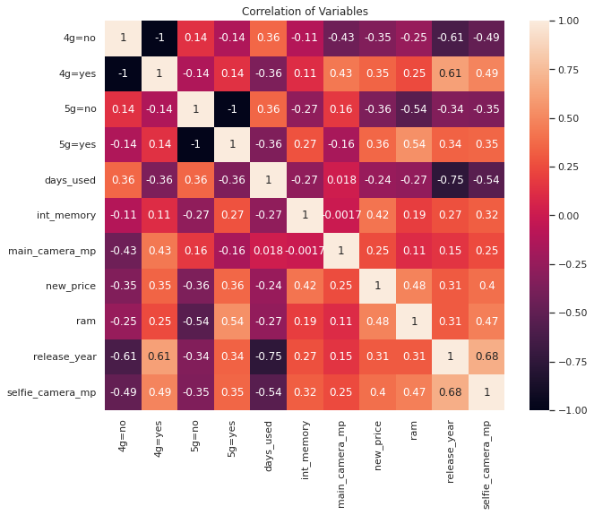

```
Variance Inflation Factors (VIF)
> 10: An indication that multicollinearity may be present
> 100: Certain multicollinearity among the variables
-------------------------------------
```

```
4g=no: inf
4g=yes: inf
5g=no: inf
5g=yes: inf
days_used: 2.5152334532089506
int_memory: 1.3396628597130176
main_camera_mp: 1.4759096605753197
new_price: 1.7098668252067821
ram: 1.8074541066012026
release_year: 3.9526030247683144
selfie_camera_mp: 2.3503606252186238

4 cases of possible multicollinearity
4 cases of definite multicollinearity

Assumption not satisfied

Coefficient interpretability will be problematic
Consider removing variables with a high Variance Inflation Factor (VIF)
```

```python
multicollinearity_assumption(liner_reg_model_2, X_train, y_train, dv.get_feature_names())
```

```
Assumption 3: Little to no multicollinearity among predictors
```

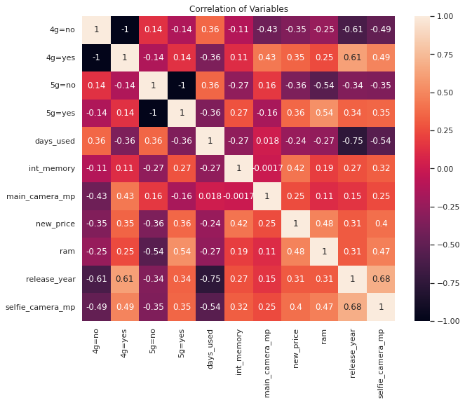

```
Variance Inflation Factors (VIF)
> 10: An indication that multicollinearity may be present
> 100: Certain multicollinearity among the variables
-------------------------------------
4g=no: inf
4g=yes: inf
5g=no: inf
5g=yes: inf
days_used: 2.5152334532089506
int_memory: 1.3396628597130176
main_camera_mp: 1.4759096605753197
new_price: 1.7098668252067821
ram: 1.8074541066012026
release_year: 3.9526030247683144
selfie_camera_mp: 2.3503606252186238

4 cases of possible multicollinearity
4 cases of definite multicollinearity

Assumption not satisfied

Coefficient interpretability will be problematic
Consider removing variables with a high Variance Inflation Factor (VIF)
```

```python
multicollinearity_assumption(liner_reg_model_2, X_train, y_train, dv.get_feature_names())
```

### Homoscedasticity

```python
def homoscedasticity_assumption(model, features, label):
    """
    Homoscedasticity: Assumes that the errors exhibit constant variance
    """
    print('Assumption 5: Homoscedasticity of Error Terms', '\n')

    print('Residuals should have relative constant variance')

    # Calculating residuals for the plot
    df_results = calculate_residuals(model, features, label)

    # Plotting the residuals
    plt.subplots(figsize=(12, 6))
    ax = plt.subplot(111)  # To remove spines
    plt.scatter(x=df_results.index, y=df_results.Residuals, alpha=0.5)
    plt.plot(np.repeat(0, df_results.index.max()), color='darkorange', linestyle='--')
    ax.spines['right'].set_visible(False)  # Removing the right spine
    ax.spines['top'].set_visible(False)  # Removing the top spine
    plt.title('Residuals')
    plt.show()
```

Test for homoscedasticity for train data

```
Assumption 5: Homoscedasticity of Error Terms

Residuals should have relative constant variance
```

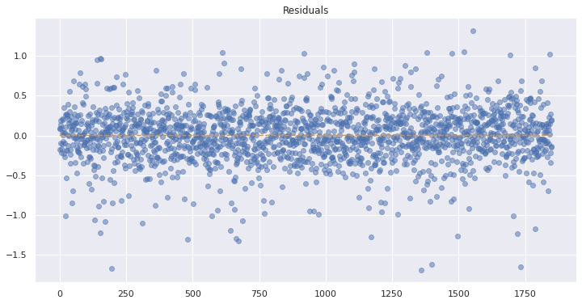

```python
homoscedasticity_assumption(liner_reg_model_2, X_train, y_train)
```

Test for homoscedasticity for Validation data

```
Assumption 5: Homoscedasticity of Error Terms

Residuals should have relative constant variance
```

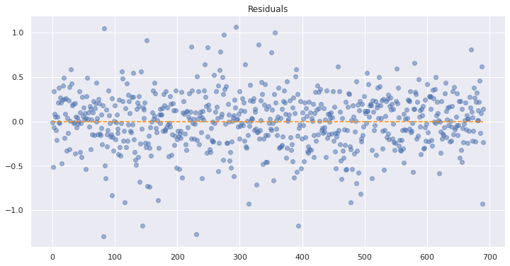

```python
homoscedasticity_assumption(liner_reg_model_2, X_valid, y_valid)
```

## Final Model Summary

```python
## Testing our final model with the test data
## check the validation accuracy
test_dict = df_test[base + categorical_var_1].to_dict(orient='records')

X_test = dv.transform(test_dict)

## generate validation predictions
y_pred_test = liner_reg_model_2.predict(X_test)

##accuracy
rme = mean_squared_error(y_test, y_pred_test)
rmse = np.sqrt(rme)
print(f'Testing Accuracy For Final Model: {rmse}')
```

```
Testing Accuracy For Final Model: 0.3215496388139157
```

## Actionable Insights and Recommendations

- As evidence with ML models, having a large dataset can improve on the accuracy of our model.
- Also, exploring other Machine learning algorithms such as Ridge regression, Decision tress can also improve the accuracy of our model.
- Exploring other forms of Parameter tunning as well can help improve on accuracy of the model.

```python
!pip freeze > requirement_fullcode.txt
```